# Project 2

Karolina Gajewska, Bartosz Piotrowski, Krzysztof Rutkowski

17.12.2015r.

# 1. Introduction

Neurology is the branch of medicine concerned with the study and treatment of disorders of the nervous system. The nervous system is a complex, sophisticated system that regulates and coordinates body activities. Different neurological problems can be described by the length of dendritic spine. The goal of this part is explaining what factors affect the length of spines. This report was prepared on the basis of the dataset dendriticSpines.rda, which is a collection of data from three different studies.

## 1.1. Data preprocessing

```r
library(lattice)
library(lme4)
library(gplots)
library(ggplot2)
```

```r
load("dendriticSpines.rda")
head(dendriticSpines)
```

```
##   Animal Photo_ID_abs spine_number    length  Study mouse treatment
## 1   7497            1            1 0.6300000 chiron    WT      dmso
## 2   7497            1            2 0.5932100 chiron    WT      dmso
## 3   7497            1            3 0.6168992 chiron    WT      dmso
## 4   7497            1            4 0.4587350 chiron    WT      dmso
## 5   7497            1            5 1.1287356 chiron    WT      dmso
## 6   7497            1            6 0.7700000 chiron    WT      dmso
```

Authors of this work discuss result from “KO” Study, where two binary conditions are crossed: the mouse ,,type’’ and the treatment.

```r
data <- dendriticSpines[dendriticSpines$Study == "ko",]
head(data)
```

```
##       Animal Photo_ID_abs spine_number    length Study mouse treatment
## 31671      1            1            1 0.6514236    ko    WT         -
## 31672      1            1            2 0.9616618    ko    WT         -
## 31673      1            1            3 1.0563098    ko    WT         -
## 31674      1            1            4 0.6377211    ko    WT         -
## 31675      1            1            5 0.4295875    ko    WT         -
## 31676      1            1            6 0.4499700    ko    WT         -
```

```r
dim(data)
```

```
## [1] 6512    7
```

In this case, the mouse ,,type’’ is one of following:

- WT (wild type) normal mice,
- KO (knock out) mice with a removed gene.

```r
unique(data$mouse)
```

```
## [1] WT KO
## Levels: KO TG WT
```

and treatments may be:

- from no treatment (-),
- lit (li)

```r
unique(data$treatment)
```

```
## [1] -  li
## Levels: - chiron dmso gm li
```

We used the function “droplevels” in order to drop unused levels from a factor or more commonly, from factors in a data frame.

```r
data$mouse <- droplevels(data$mouse)
data$treatment <- droplevels(data$treatment)
```

## 1.2 Goal for phase 1

Finding a interaction between the mouse type and the treatment.

# 2. Creating model

We build two models, with and without contrasts. We treat mouse and treatment effects as constant effects and animal effect as randrom effect and use mixed model. Firstly we have not so much observations so we chose model with less number of parameters. Secondly there is a small number of mouses, number of sample is very small comparing to whole population.

```r
#without contrasts

model1 = lmer(length~mouse*treatment + (1|Animal:mouse:treatment), data=data)

coefs1 <- summary(model1)$coefficients[2:4,3]
```

```r
#with contrasts

model2 = lmer(length~mouse*treatment + (1|Animal:mouse:treatment), data=data,
              contrasts = list(mouse="contr.sum", treatment="contr.sum"))
coefs2 <- summary(model2)$coefficients[2:4,3]
```

# 3. Model validation

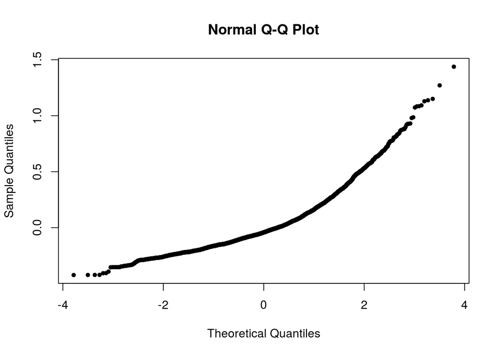

```r
e = residuals(model2)
qqnorm(e, pch=20)
```

Unfortunatelly, based on theoretical quantiles chart for normal distribution we see that the rest of the model is not characterized by a normal distribution.

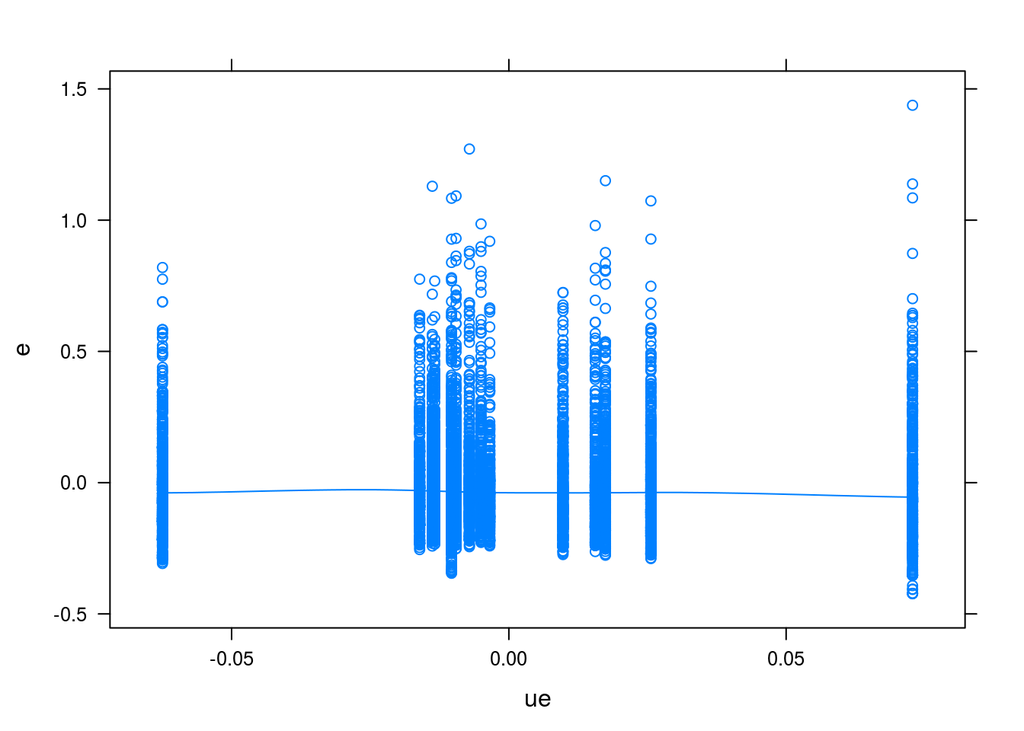

```r
u = ranef(model2, condVar=T)
z = model.matrix(~factor(Animal)-1, data)
ue = z %*% u[[1]][[1]]
xyplot(e~ue, type=c("p", "smooth"))
```

# 4. Test for effect of an interaction

Now, we choose a level of confidence - alpha = 0.05 and use Wald test.

```r
alpha = 0.05
c = -qnorm(alpha/2)
# c= 1.959964
interactions1 <- (abs(coefs1) > c)
interactions2 <- (abs(coefs2) > c)
interactions2
```

```
##            mouse1        treatment1 mouse1:treatment1
##              TRUE              TRUE              TRUE
```

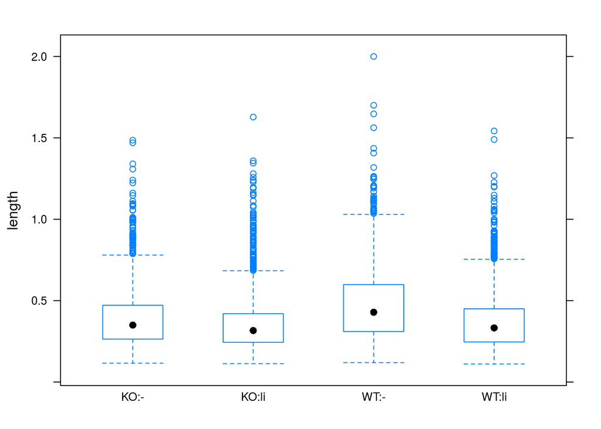

```r
bwplot(length~mouse:treatment, data=data)
```

Let’s point out, that for both kind of treatments, normal mice have bigger value of lenght of dendritic spine than mice with a removed gene. However, what is important, we can observe significant differences between kind of mice in “from no treatment”.

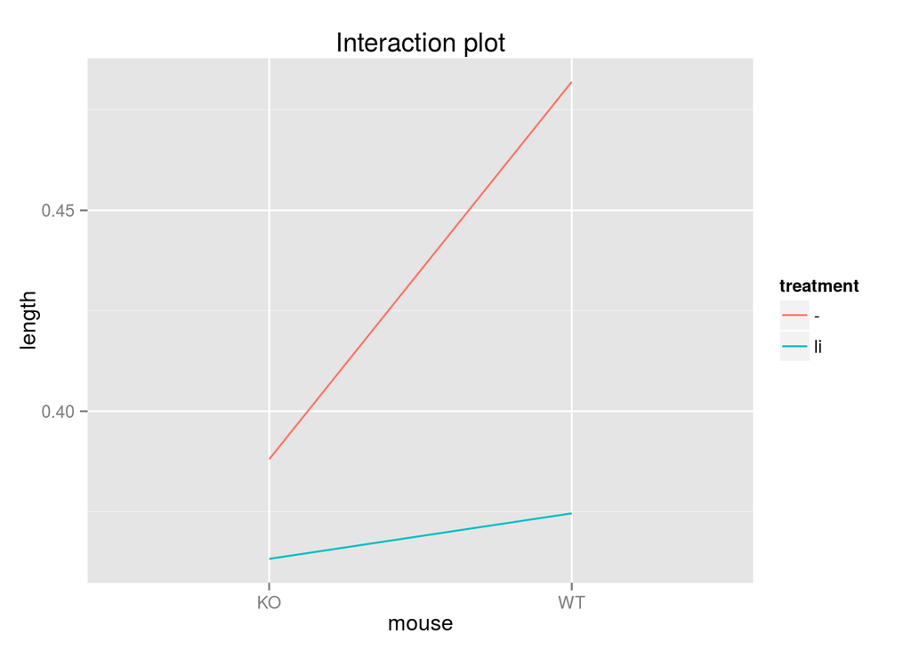

```r
ggplot(data=data, aes(x=mouse, y=length, group=treatment, colour=treatment)) + stat_summary(fun.y= mean, geom="line") +ggtitle("Interaction plot")
```

# 5. Diagnosis of random effects

```
## $`Animal:mouse:treatment`
```

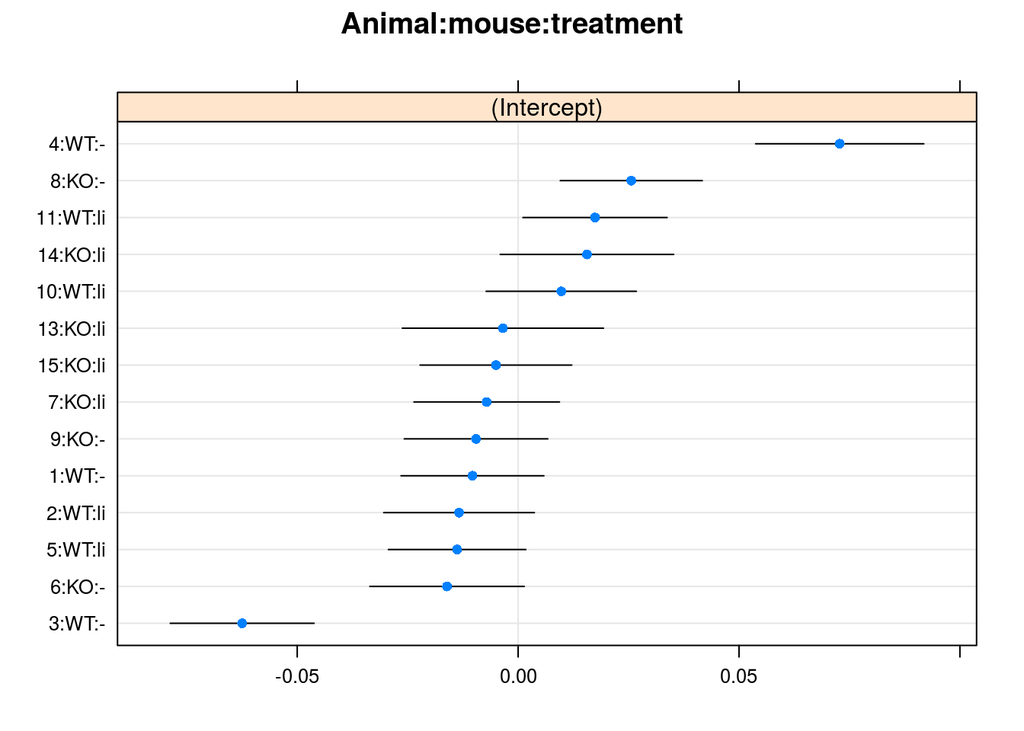

```r
u = ranef(model2, condVar=T)
dotplot(u)
```

# 6. Conslusion

In first phase of project 2, we tried to explain what factors affect the length of spines. According to recommendation, we test if there is an interaction between the mouse type and the treatment. In case for “KO” study, we can say, that the most important influence has kind of treatment.